# Replication: ‘On the Role of Alternatives in the Acquisition of Simple and Complex Disjunctions in French and Japanese’ by Tieu et al (2016, Journal of Semantics)

Masoud Jasbi (Department of Linguistics, Stanford University)

March 26, 2017

## Introduction

Tieu et al. (2016) investigated children and adults’ interpretation of the french simple (*…ou…*) and complex (*soit … soit …*) disjunction constructions as well as the Japanese ones (*…ka…*/*ka…ka…*). They concluded the following:

> The main findings from our experiment are that both French- and Japanese-speaking children interpreted the simple and complex disjunctions either inclusively or conjunctively; in contrast, adults generally accessed exclusive readings of both disjunctions.

This replication study investigates the second claim: that adults interpret simple and complex disjunction as exclusive disjunction. There are two major differences between this replicaton and the original study: 1. this replication study is done in English. The original study was in French and Japanese. 2. this replication is web-based and uses Amazon’s Mechanical Turk for recruiting. The original study was conducted in a lab and recruited university students.

## Methods

Here I report the original paper’s explanation of the materials and procedure. You can see the online version of the study at https://web.stanford.edu/~masoudj/tieu_replication/study1.html.

### Materials

> There were three conditions involving disjunctive test sentences such as “The hen pushed the bus or the airplane”. In the target ‘1-disjunct-true’ (1DT) condition, the outcome of the story was such that only one of the disjuncts was verified, for example, the hen pushed only the bus. In the target ‘2-disjunct-true’ (2DT) condition, the outcome of the story was such that both disjuncts were verified, for example, the hen would push both the bus and the airplane. Participants also saw a ‘0-disjunct-true’ (0DT) control condition, in which the hen would push neither object, as well as filler sentences that did not contain disjunction. All test and control sentences can be found in the Appendix. Each participant saw four repetitions of both the 1DT condition and 2DT conditions, two repetitions of the 0DT control condition, and three disjunction-less fillers, for a total of 13 experimental trials. These 13 trials, presented in one of two pseudorandomized orders, were preceded by two training items: on one practice trial, the puppet made a guess that turned out to be clearly verified, and on the second, the puppet made a guess that turned out to be clearly wrong. The purpose of the practice trials was to show that the puppet was capable of making both good and bad guesses, and more generally to familiarize the participants with the task.

### Procedure

> We used a modified Truth Value Judgment Task (Crain & Thornton 1998, 2000) in Prediction mode, presented to the participants in the form of a ‘guessing game’. Participants were introduced to a puppet named Raffie the Giraffe, and were told that they would play a game with her on the computer. Pre-recorded videos of the puppet’s utterances created the ruse that the puppet was participating live via webcam. The reason we chose to run the task in Prediction mode rather than the typical Description mode, where the puppet describes an event that has already unfolded, was meant to make the use of disjunction felicitous. In particular, the use of disjunction typically gives rise to an ignorance inference that the speaker does not know which of the two disjuncts holds. If uttered in Description mode then, the puppet’s assertion could have potentially given rise to infelicity, given the puppet had just witnessed the relevant event unfold. Each trial consisted of three stages (see Figure 1). First, the participant would see a picture and hear a short introduction about the character in the picture. In the second step, the puppet would appear on the screen to make a guess about what would happen next in the story.8 At this stage, children would also be prompted to repeat the puppet’s sentence, to ensure that they had correctly heard the statement. In the final scene, participants saw the outcome, and had to decide if the puppet had guessed correctly or not. Participants had to stamp under a happy or sad face on a scorecard to indicate their responses. We also elicited follow-up justifications after affirmative and negative responses, in order to ascertain children’s reasoning for their responses. All children were tested individually in a quiet room away from their peers. Their responses were videorecorded for later analysis. Adult control participants were also tested one at a time, using exactly the same materials and procedure.

### Original Data and Exclusion

The exclusion criteria as stated in the original paper:

> These numbers exclude three Japanese and five French children who failed to pass the control trials. An additional two French children were excluded as it was reported that their first language was English. Finally, two Japanese adults were excluded for making at least two errors on control trials.

In addition to the exclusion criteria in the original paper, in the replication study, I exclude participants that spent less than 20 seconds watching the experimental videos. The length of each video is at least 28 seconds.

Below you can see the original paper’s data wrangling code and the exclusion procedure.

```r
# Original code from Tieu et al (2016). Comments by Masoud Jasbi.
Y<-read.csv("../0_original_study/TYCRSC_AcqDisj.csv")

# Creating a long-form data-frame for subjects to apply the exclusion criterion
infos.subject<-data.frame(
PARTICIPANT=tapply(as.character(Y$participant), Y$participant, max),
TYPE=tapply(as.character(Y$AgeGroup), Y$participant, max),
LANG=tapply(as.character(Y$Lang), Y$participant, max),
AGE=tapply(Y$ageD, Y$participant, max),
SITE=tapply(as.character(Y$exp.site), Y$participant, max),
VERSION=tapply(as.character(Y$version), Y$participant, max),
COMPLEX=tapply((Y$Complex), Y$participant, max)
)

# Create a column with the proportion of correct responses in the control conditions
infos.subject$Correct<-tapply(Y$correct[Y$Condition=="Control"],Y$participant[Y$Condition=="Control"],mean,na.rm=T)

# Store IDs of subjects that were correct in control trials less than %70 of the time
excluded<-infos.subject$PARTICIPANT[infos.subject$Correct<.7]

# Remove training items and excluded participants stored in "excluded"
Y<-subset(Y,Condition!="Training" & !participant%in%excluded)

# Remove the control trials and "both" type responses (e.g., "She was right and she wasn't right").
original_data<-subset(Y,Condition!="Control"&response!=0.5) #variable name originally "data"

# my code here:
original_data$Complex <- as.factor(original_data$Complex)
levels(original_data$Complex) <- c("Simple","Complex") #explicitly naming the disjunction types
original_data <- rename(original_data, Disjunct=Complex) #changing the column name to Disjunct
```

Below, I provide a summary of the data in the orignal study. The table shows the proportion of adults who said that the puppet’s guess was right for each language, disjunction type, and condition.

```r
#Summarize the data to have proportions of yes/no responses for each condition and disjunct type in each language
summary_originaldata <-
  original_data %>%
  group_by(participant, Lang, AgeGroup, Disjunct, Condition, response) %>%
  summarise(counts = n()) %>% #count the number of Yes and No responses per participant
  spread(response, counts) %>% #make a column out of the coutns of response types
  replace(is.na(.), 0) %>%
  mutate(total = `0` + `1`) %>%
  gather(trial, counts, `0`, `1`) %>%
  mutate(prop = counts / total) %>%
    group_by(Lang, AgeGroup, Disjunct, Condition, trial) %>%
    summarize(cih = ci.high(prop),
              cil = ci.low(prop),
              prop = mean(prop))

adult_table <-
summary_originaldata %>%
  filter(AgeGroup=="adult", trial==1, Lang!="English") %>%
  select(Lang, Disjunct, Condition, prop)

kable(adult_table, digits = 2)
```

| AgeGroup | Lang | Disjunct | Condition | prop |
| --- | --- | --- | --- | --- |
| adult | French | Simple | 1DT | 0.98 |
| adult | French | Simple | 2DT | 0.05 |
| adult | French | Complex | 1DT | 1.00 |
| adult | French | Complex | 2DT | 0.00 |
| adult | Japanese | Simple | 1DT | 1.00 |
| adult | Japanese | Simple | 2DT | 0.15 |
| adult | Japanese | Complex | 1DT | 1.00 |
| adult | Japanese | Complex | 2DT | 0.09 |

### Participants

The table below summarizes the participant information for the original study.

| Language | Disjunct | Adult | Child |
| --- | --- | --- | --- |
| French | Simple | 10 | 14 |
| French | Complex | 10 | 14 |
| Japanese | Simple | 10 | 11 |
| Japanese | Complex | 11 | 7 |

### Power Analysis

The differences between 1DT and 2DT trials are quite drastic. The code below calculates the effect size for these trials and uses it to estimate the number of participants needed to achieve %95 power in the replication study.

```r
subject_means <-
original_data %>%
group_by(participant, Lang, AgeGroup, Disjunct, Condition, response) %>%
summarise(counts = n()) %>% #count the rows
spread(response, counts) %>%
replace(is.na(.), 0) %>%
mutate(total = `0` + `1`) %>%
gather(trial, counts, `0`, `1`) %>%
mutate(prop = counts / total) %>%
  filter(AgeGroup=="adult", trial==1, Lang=="French")

one_dt<- subject_means %>%
  filter(Condition=="1DT")
two_dt<- subject_means %>%
  filter(Condition=="2DT")

cohens_d <- cohen.d(one_dt$prop, two_dt$prop)$estimate

pwr.t.test(n = NULL, d = cohens_d, sig.level = 0.05, power = 0.95,
    type = "paired")
```

```
##
##      Paired t test power calculation
##
##               n = 2.082246
##               d = 14.31153
##       sig.level = 0.05
##           power = 0.95
##     alternative = two.sided
##
## NOTE: n is number of *pairs*
```

The effect size is 14.31, and the analysis to achieve 95% power suggests we can collect data from 3 participants. However, to be cautious I still stick to the original sample size of 20.

### Planned Sample

I plan to run the study with 20 adult native speakers of English. I will use Amazon Mechanical Turk to recruit participants which restricts the participants to the US and American English speakers (mostly).

### Analysis Plan

The original study was interested in the differences between the interpretations of adults and children. Here I am focusing on adults only. The key analysis is the difference in mean proportions of “yes” responses in 1DT vs. 2DT trials. I calculate this using the paired t-test below.

```r
t.test(one_dt$prop, two_dt$prop, paired = T)
```

```
##
##  Paired t-test
##
## data:  one_dt$prop and two_dt$prop
## t = 35.184, df = 19, p-value < 2.2e-16
## alternative hypothesis: true difference in means is not equal to 0
## 95 percent confidence interval:
##  0.9052431 1.0197569
## sample estimates:
## mean of the differences
##                  0.9625
```

### Differences from Original Study

This replication differs with the original study in two main ways. First the language under investigation and second the medium of testing. The original study was conducted in French and Japanese. This study is conducted in English. In the original study, adult participants responded to the experimental questions in a lab setting. In this study I use Amazon Mechanical Turk and recruit participants using the web. I do not expect these differences to affect the results siginficantly.

## Results

### Data preparation

Here I load the replication data and store them in one data frame with the data from the original study.

```r
# Load the English English data
english_rawdata <- read_csv("../2_processed_data/adult_data.csv")

# exclude participants that spent less than 20 seconds on a trial
english_rawdata <- filter(english_rawdata, duration>20000)
# No participant was excluded

# pick the right rows and columns for analysis
english_analysis_data <-
  english_rawdata %>%
  separate(trials, c("Disjunct","Condition", "item"), sep="_") %>% #create the disjunct and condition columns
  filter(Condition=="1DT" | Condition=="2DT") %>% #get rid of controls and training trials
  select(participant, Lang, Disjunct, Condition, response, AgeGroup)

english_analysis_data$Disjunct <- as.factor(english_analysis_data$Disjunct)
#Capitalize simple and complex!
english_analysis_data$Disjunct <- fct_recode(english_analysis_data$Disjunct, Simple = "simple", Complex = "complex")

#pick the columns you want for the analysis in the original data set
original_analysis_data <-
  original_data %>%
  select(participant, Lang, Disjunct, Condition, response, AgeGroup)

#create a unified dataset of English-replicated and original data
analysis_data <-
  bind_rows(english_analysis_data, original_analysis_data)

#Summarize the data to have proportions of yes/no responses for each condition and disjunct type in each language
summary_data <-
  analysis_data %>%
  group_by(participant, Lang, AgeGroup, Disjunct, Condition, response) %>%
  summarise(counts = n()) %>% #count the number of Yes and No responses per participant
  spread(response, counts) %>% #make a column out of the counts of response types
  replace(is.na(.), 0) %>%
  mutate(total = `0` + `1`) %>%
  gather(trial, counts, `0`, `1`) %>%
  mutate(prop = counts / total) %>%
    group_by(Lang, AgeGroup, Disjunct, Condition, trial) %>%
    summarize(cih = ci.high(prop),
              cil = ci.low(prop),
              prop = mean(prop))
```

#### Actual Sample

The table below shows the number of participants in each condition of the replication. No participant in this replication met the criteria for exclusion.

| Language | Disjunct | Adult | Child |
| --- | --- | --- | --- |
| ENGLISH | Complex | 11 | NA |
| ENGLISH | Simple | 9 | NA |

### Confirmatory analysis

The plot below shows the percentage of “yes” responses in the original (French and Japanese), as well as the replication study (ENGLISH). The replication in English shows the same pattern observed in the original study. Adult accepted a disjunction when only one of the disjuncts was true but rejected it when both disjuncts were true.

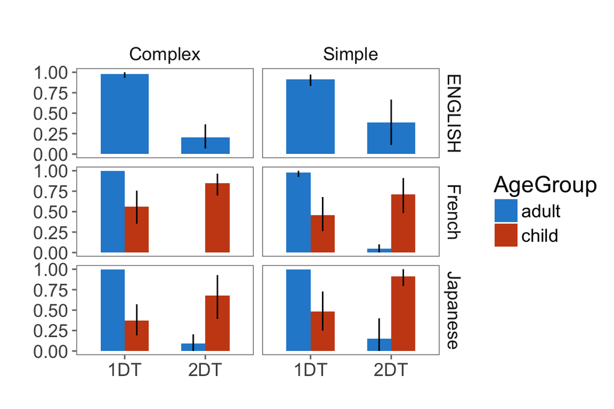

Error bars show 95% confidence intervals.

```r
subject_means_eng <-
original_data %>%
group_by(participant, Lang, AgeGroup, Disjunct, Condition, response) %>%
summarise(counts = n()) %>% #count the rows
spread(response, counts) %>%
replace(is.na(.), 0) %>%
mutate(total = `0` + `1`) %>%
gather(trial, counts, `0`, `1`) %>%
mutate(prop = counts / total) %>%
  filter(AgeGroup=="adult", trial==1, Lang=="English")

one_dt_eng<- subject_means %>%
  filter(Condition=="1DT")
two_dt_eng<- subject_means %>%
  filter(Condition=="2DT")

cohens_d_eng <- cohen.d(one_dt_eng$prop, two_dt_eng$prop)$estimate

final_test <- t.test(one_dt_eng$prop, two_dt_eng$prop, paired = T)
```

## Discussion

The results obtained by Tieu et al. (2016) for French and Japanese speaking adults were replicated here for English speaking adults: they accepted disjunctive sentences such as “The chicken pushed the bus or the plane” when only one of the events were true and rejected them when both were true. The replication data suggests that in English, complex disjunction of the form “either A or B” may carry more exclusivity implication than simple disjunction like “A or B”. However, this effect is small and requires more participants than collected for the purposes of this replication.

## Bibliography

Tieu, L., K. Yatsushiro, A. Cremers, J. Romoli, U. Sauerland, and E. Chemla. 2016. “On the Role of Alternatives in the Acquisition of Simple and Complex Disjunctions in French and Japanese.” *Journal of Semantics*.